# <font color=Pink> **Name:** <font color=blue> PRASHANT VERMA </font>

# <font color=Blue> **Data Analysis** </font>

## 1. Date of Birth (Age) Analysis:

=> Analysis and visualization of Facebook users from their birth date.

=> Analysis and visualization of Facebook users from their birth month.

=> Need to visualize number of facebook users in different age groups.

=> Need to visualize number of facebook users as per their gender in different age groups.

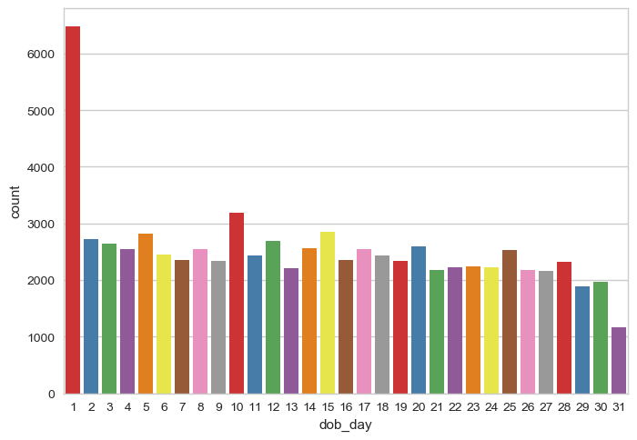

```python
# Analysis and visualization of Facebook users from their birth date.
ax = sns.countplot(x="dob_day", data=fbd, palette="Set1")
```

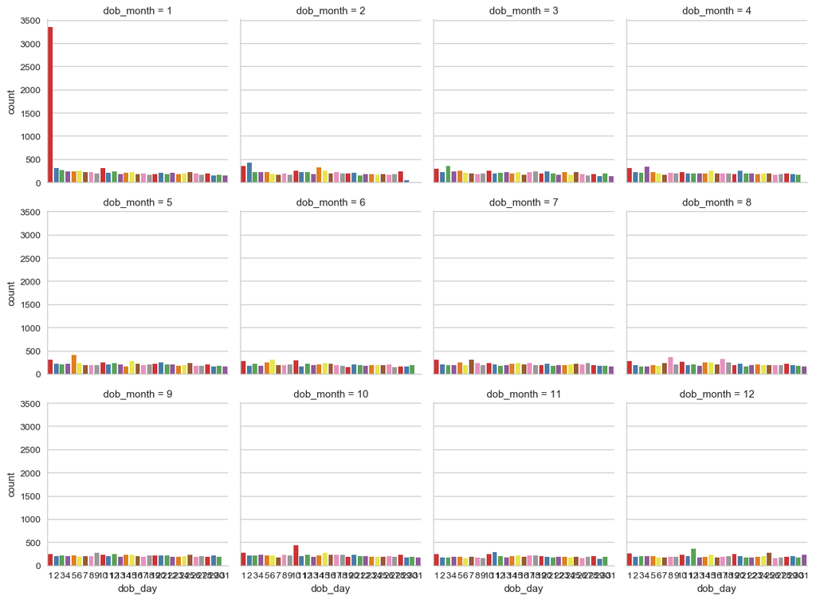

```python
# Analysis and visualization of Facebook users from their birth month.
ax = sns.factorplot(x="dob_day", col="dob_month", data=fbd, col_wrap=4, kind="count", palette="Set1", size=3, aspect=1)
```

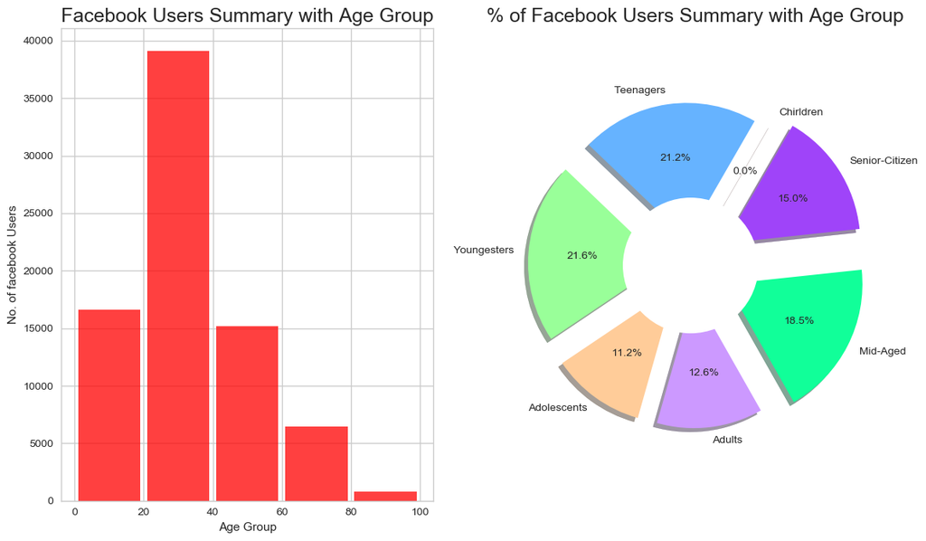

```python
# Age Group Analysis on histrogram and piechart to visualize more facebook users.
total_user_count=fbd['age'].groupby(fbd['Age_Group']).agg(['count', 'sum', 'mean', 'min', 'max'])

fig = plt.figure(figsize=(12,7))

plt.subplot(1,2,1)
bin_edges = [0,20,40,60,80,100]
plt.hist(fbd['age'], bins=bin_edges, facecolor='r', alpha=0.75, rwidth=0.9)
plt.xlabel('Age Group')
plt.ylabel('No. of facebook Users')
plt.title('Facebook Users Summary with Age Group', fontsize=18)
plt.grid(True)


plt.subplot(1,2,2)
#labels = ['0-13', '13-20', '20-25', '25-30', '30-40', '40-60', '60-100']
labels = ['Chirldren', 'Teenagers', 'Youngesters', 'Adolescents', 'Adults', 'Mid-Aged', 'Senior-Citizen']
sizes = fbd.Age_Group.value_counts()
sizes =[0,20983,21344,11071,12491,18287,14827]
explode =(0.2,0.2,0.2,0.2,0.2,0.3,0.3)
colors = ['#ff9999','#66b3ff','#99ff99','#ffcc99','#cc99ff','#11ff99','#9f44f9']
plt.pie(sizes, explode=explode, labels=labels, colors = colors, autopct='%1.1f%%', shadow=True, startangle=60)
plt.title('% of Facebook Users Summary with Age Group', fontsize=18)


# Drawing circle
centre_circle = plt.Circle((0,0),0.50,fc='white')
fig = plt.gcf()
fig.gca().add_artist(centre_circle)

# Equal aspect ratio ensures that pie is drawn as a circle.
plt.axis('equal')
plt.tight_layout()
plt.show()
```

[figure not shown]

```python
# Drawing a factor plot to get visualization of Facebook Users as per their Gender from different age group.
pkmn_type_colors = ['#ff9999','#66b3ff']  # FE, # MA

fig = plt.figure(figsize=(15,7))
sns.factorplot(x='Age_Group', hue='gender', data=fbd, kind='count', palette= pkmn_type_colors, size=7)
locs, title = plt.xticks()
plt.xticks(locs)
plt.xlabel('Age Group')
plt.ylabel('No. of Facebook Users')
plt.title('Categorization of Facebook Users as per their Gender in different Age Group', fontsize=18)
plt.tight_layout()
plt.show()
```

<font color=green> **Observation:** This graph shows that mejority of Facebook Users are Males with respect to Females in all age group users.

Though, this trend deficed by Females as mejor Facebook Users in comparison of Males for Senior-Citizen (60-100 age) age group. </font>

## 2. Friend Count Analysis:

=> Need to visualize total and average number of friends in different age group.

=> Need to visulaize spread of friends count as per gender-wise in different age group.

=> Need to visualize average number of friendship request initiated in different age groups as per theier gender.

=> Need to visualize total and average number of friends as per gender-wise in different age group.

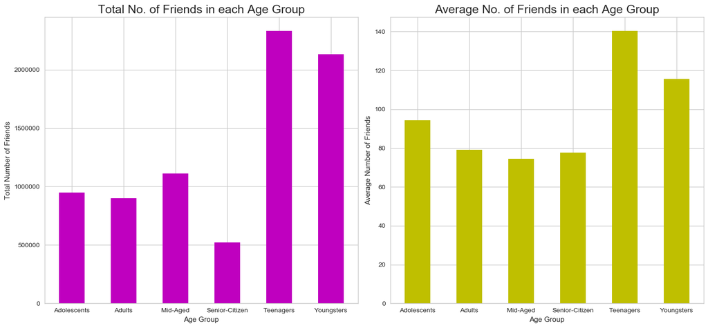

```python
# Drawing bar plots to visualize total and average number of friends in each age group.
total_friends_count=fbd['friend_count'].groupby(fbd['Age_Group']).agg(['count', 'sum', 'mean', 'min', 'max'])

fig = plt.figure(figsize=(15,7))
plt.subplot(1,2,1)
plt.bar(total_friends_count.index, total_friends_count['sum'], color='m', width=0.5)
locs, title = plt.xticks()
plt.xticks(locs) #('0-13','13-20','20-25','25-30','30-40','40-60', '60-100'))
plt.title('Total No. of Friends in each Age Group', fontsize=18)
plt.ylabel('Total Number of Friends')
plt.xlabel('Age Group')

plt.subplot(1,2,2)
plt.bar(total_friends_count.index, total_friends_count['mean'], color='y', width=0.5)
locs, title = plt.xticks()
plt.xticks(locs) #('0-13','13-20','20-25','25-30','30-40','40-60', '60-100'))
plt.title('Average No. of Friends in each Age Group', fontsize=18)
plt.ylabel('Average Number of Friends')
plt.xlabel('Age Group')

plt.tight_layout()
plt.show()
```

<font color=green> **Observation:** These graph shows that Teenagers toped in Total No. of Friends Counts, among other Age groups of Facebook Users, followed by Youngesters and then Mid-aged.

Though, this trend keeps following in same way in Average No. of Friends Counts ranked on top by Teenages among other age-groups, followed by Youngesters and then Adolesent. </font>

```python
# Resetting the index of total_friends_count column.
total_friends_count.reset_index()
```

|  | Age_Group | count | sum | mean | min | max |
| --- | --- | --- | --- | --- | --- | --- |
| 0 | Adolescents | 10053 | 947205 | 94.221128 | 0 | 439 |
| 1 | Adults | 11384 | 899938 | 79.052881 | 0 | 438 |
| 2 | Mid-Aged | 14967 | 1113481 | 74.395737 | 0 | 439 |
| 3 | Senior-Citizen | 6705 | 521611 | 77.794333 | 0 | 439 |
| 4 | Teenagers | 16617 | 2332220 | 140.351447 | 0 | 439 |
| 5 | Youngsters | 18434 | 2130987 | 115.600901 | 0 | 439 |

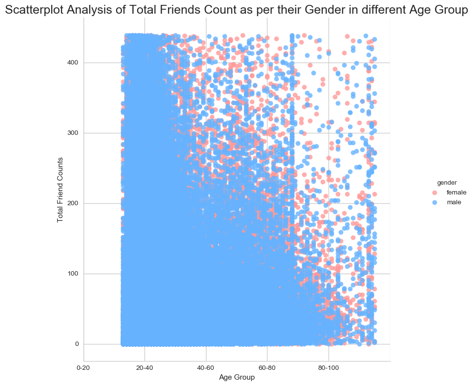

```python
# Scatterplot visulaizing spread of Total Friends Count as per their gender in different age group.
sns.lmplot('age', 'friend_count', data=fbd, fit_reg=False, hue="gender",palette=pkmn_type_colors, size=8)
locs, title = plt.xticks()
plt.xticks(locs,('0-20','20-40','40-60','60-80','80-100'))
plt.xlabel('Age Group')
plt.ylabel('Total Friend Counts')
plt.title('Scatterplot Analysis of Total Friends Count as per their Gender in different Age Group', fontsize=18)
plt.tight_layout()
plt.show()
```

<font color=green> **Observation:** This scatter-plot graph shows Teenagers and Youngesters are on top in Total No. of Friends Count which is keep degrading with the age increases as it implies that they don't feel comfirtable to make new friends in other agre gorups of life. </font>

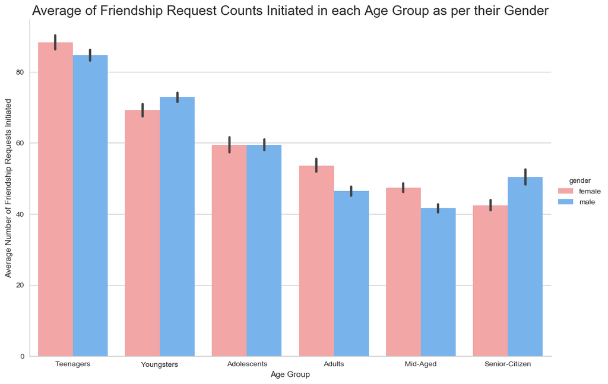

```python
# Plotting graph to visualize average number of friendship request initiated in different age groups as per theier gender.
sns.factorplot(x="Age_Group", y="friendships_initiated", data=fbd, kind="bar", hue='gender', aspect=1.5, palette=pkmn_type_colors, size=7)
locs, title = plt.xticks()
plt.xticks(locs) #('0-13','13-20','20-25','25-30','30-40','40-60', '60-100'))
plt.xlabel('Age Group')
plt.ylabel('Average Number of Friendship Requests Initiated')
plt.title('Average of Friendship Request Counts Initiated in each Age Group as per their Gender', fontsize=18)
plt.show()
```

<font color=green> **Observation:** This graph shows that Females from Teenagers, Adults and Mid-Aged groups, leads with Males in initiating the Facebook Friend Requests.

Though, Male from Youngsters, Adolescents and Senior-Citizen are also leading with Females in initiating the Facebook Friend Requests. </font>

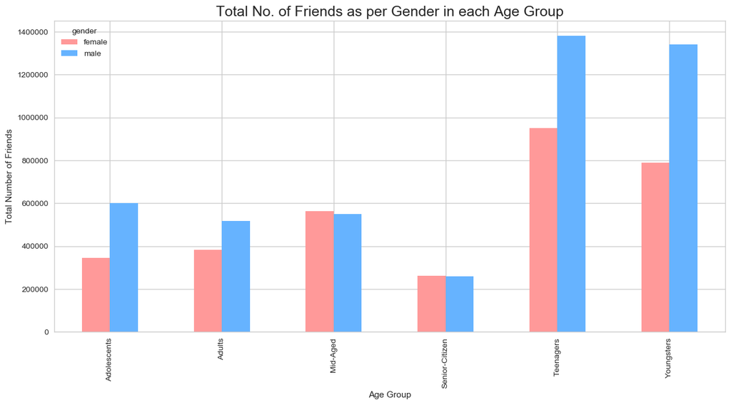

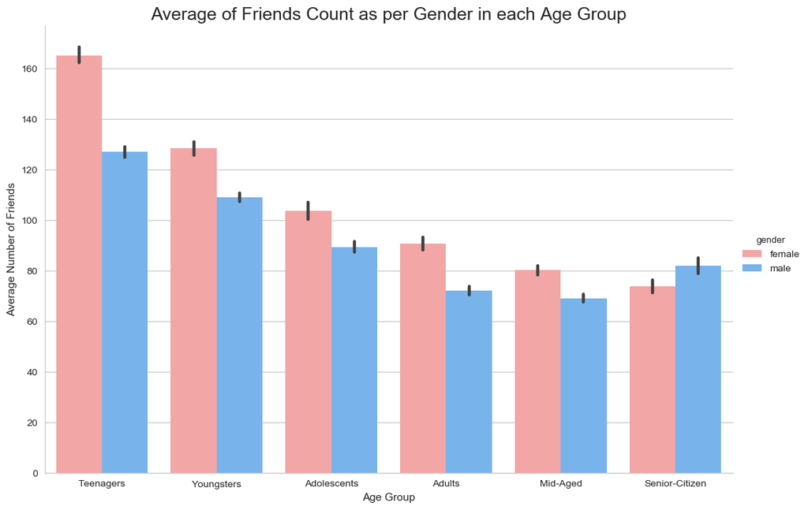

```python
# Drawing bar plots to visualize total and average number of friends as per their gender in each age group.
total_friends_count=fbd['friend_count'].groupby([fbd['Age_Group'],fbd['gender']]).sum()

colors = ['#ff9999','#66b3ff']     # FE, # MA
total_friends_count.unstack('gender').plot(kind='bar', subplots=False, color=colors, figsize=(15,7))
locs, title = plt.xticks()
plt.xticks(locs) #('0-13','13-20','20-25','25-30','30-40','40-60', '60-100')
plt.title('Total No. of Friends as per Gender in each Age Group', fontsize=18)
plt.ylabel('Total Number of Friends')
plt.xlabel('Age Group')
plt.show()


pkmn_type_colors = ['#ff9999','#66b3ff']  # FE, # MA
sns.factorplot(x="Age_Group", y="friend_count", data=fbd, kind="bar", hue='gender', aspect=1.5, size=7, palette=pkmn_type_colors)
locs, title = plt.xticks()
plt.xticks(locs) #('0-13','13-20','20-25','25-30','30-40','40-60', '60-100'))
plt.xlabel('Age Group')
plt.ylabel('Average Number of Friends')
plt.title('Average of Friends Count as per Gender in each Age Group', fontsize=18)
plt.show()
```

<font color=green> **Observation:** First graph shows that Males from all groups, have more Total Number of Friends as comparison to Females except in Mid-Aged and Senior Citizen age group.

Second graph shows that Females have more Average Number of Friends than Male counterparts in all Age Groups except in Senior-Citizen group. </font>

```python
# Resetting the index of total_friends_count column.
total_friends_count.reset_index()
```

|  | Age_Group | gender | friend_count |
| --- | --- | --- | --- |
| 0 | Adolescents | female | 346069 |
| 1 | Adolescents | male | 601136 |
| 2 | Adults | female | 381573 |
| 3 | Adults | male | 518365 |
| 4 | Mid-Aged | female | 562890 |
| 5 | Mid-Aged | male | 550591 |
| 6 | Senior-Citizen | female | 262523 |
| 7 | Senior-Citizen | male | 259088 |
| 8 | Teenagers | female | 950221 |
| 9 | Teenagers | male | 1381999 |
| 10 | Youngsters | female | 790086 |
| 11 | Youngsters | male | 1340901 |

## 3. Tenure Analysis:

=> Need to visulaize total number of users joined Facebook each year as per their gender.

=> Need to visualize total number of friendship request initiated each year as per theier gender.

=> Need to visualize total number of friends added each year as per theier gender.

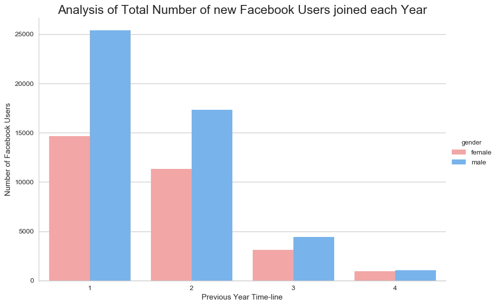

```python
# Analysis of total number of users joined Facebook each year as per their gender.
total_user_count=fbd['tenure'].groupby([fbd['Tenure_Year'],fbd['gender']]).agg(['count', 'sum', 'mean', 'min', 'max'])
sns.factorplot(x='Tenure_Year', data=fbd, kind='count', hue='gender', size=6, aspect=1.5, palette=pkmn_type_colors)
locs, title = plt.xticks()
plt.xticks(locs,('1','2','3','4','5','6','7'))
plt.title('Analysis of Total Number of new Facebook Users joined each Year', fontsize=18)
plt.ylabel('Number of Facebook Users')
plt.xlabel('Previous Year Time-line')
plt.show()
```

<font color=green> **Observation:** Above graph shows that Males were more active than Females who joined Facebook in previous years of timeline. </font>

```python
# Resetting the index of total_user_count column.
total_user_count.reset_index()
```

|  | Tenure_Year | gender | count | sum | mean | min | max |
| --- | --- | --- | --- | --- | --- | --- | --- |
| 0 | 1 year | female | 14648 | 2.920358e+06 | 199.369061 | 0.0 | 365.0 |
| 1 | 1 year | male | 25373 | 4.806532e+06 | 189.434911 | 0.0 | 365.0 |
| 2 | 2 year | female | 11302 | 5.817915e+06 | 514.768615 | 366.0 | 730.0 |
| 3 | 2 year | male | 17306 | 8.938669e+06 | 516.506934 | 366.0 | 730.0 |
| 4 | 3 years | female | 3127 | 2.751105e+06 | 879.790534 | 731.0 | 1095.0 |
| 5 | 3 years | male | 4443 | 3.908113e+06 | 879.611299 | 731.0 | 1095.0 |
| 6 | 4 years | female | 925 | 1.096202e+06 | 1185.083243 | 1096.0 | 1278.0 |
| 7 | 4 years | male | 1036 | 1.224667e+06 | 1182.111004 | 1096.0 | 1278.0 |

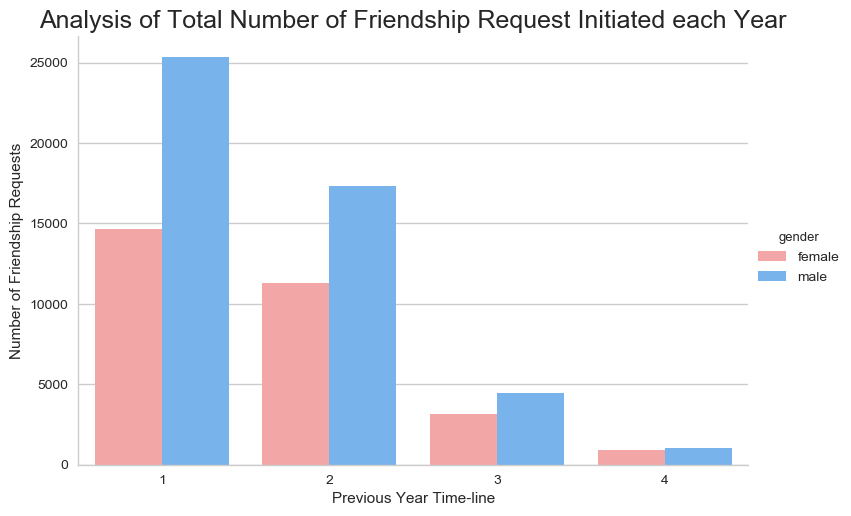

```python
# Analysis of total number of friendship requests initiated each year as per their gender.
total_initiated_friendship_count=fbd['friendships_initiated'].groupby([fbd['Tenure_Year'],fbd['gender']]).agg(['count', 'sum', 'mean', 'min', 'max'])
sns.factorplot(x='Tenure_Year', data=fbd, kind='count', hue='gender', size=5, aspect=1.5, palette=pkmn_type_colors)
locs, title = plt.xticks()
plt.xticks(locs,('1','2','3','4','5','6','7'))
plt.title('Analysis of Total Number of Friendship Request Initiated each Year', fontsize=18)
plt.ylabel('Number of Friendship Requests')
plt.xlabel('Previous Year Time-line')
plt.show()
```

<font color=green> **Observation:** Above graph shows that Males were more active in initiating Facebook Friend Request than Females in previous years of timeline. </font>

```python
# Resetting the index of total_initiated_friendship_count column.
total_initiated_friendship_count.reset_index()
```

|  | Tenure_Year | gender | count | sum | mean | min | max |
| --- | --- | --- | --- | --- | --- | --- | --- |
| 0 | 1 year | female | 14648 | 803511 | 54.854656 | 0 | 417 |
| 1 | 1 year | male | 25373 | 1397824 | 55.091002 | 0 | 426 |
| 2 | 2 year | female | 11302 | 769166 | 68.055742 | 0 | 390 |
| 3 | 2 year | male | 17306 | 1279622 | 73.940945 | 0 | 414 |
| 4 | 3 years | female | 3127 | 206883 | 66.160217 | 0 | 410 |
| 5 | 3 years | male | 4443 | 295305 | 66.465226 | 0 | 358 |
| 6 | 4 years | female | 925 | 60118 | 64.992432 | 0 | 366 |
| 7 | 4 years | male | 1036 | 66572 | 64.258687 | 0 | 373 |

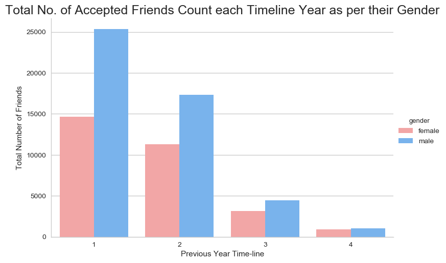

```python
# Analysis of total number of accepted friend-count in each Facebook Timeline year as per their gender.
total_timeline_friends_count=fbd['friend_count'].groupby([fbd['Tenure_Year'],fbd['gender']]).count()
sns.factorplot(x='Tenure_Year', data=fbd, kind='count', hue='gender', size=5, aspect=1.5, palette=pkmn_type_colors)
locs, title = plt.xticks()
plt.xticks(locs,('1','2','3','4','5','6','7'))
plt.title('Total No. of Accepted Friends Count each Timeline Year as per their Gender', fontsize=18)
plt.ylabel('Total Number of Friends')
plt.xlabel('Previous Year Time-line')
plt.show()
```

```python
# Resetting the index of total_friendship_count column.
total_timeline_friends_count.reset_index()
```

|  | Tenure_Year | gender | friend_count |
| --- | --- | --- | --- |
| 0 | 1 year | female | 14648 |
| 1 | 1 year | male | 25373 |
| 2 | 2 year | female | 11302 |
| 3 | 2 year | male | 17306 |
| 4 | 3 years | female | 3127 |
| 5 | 3 years | male | 4443 |
| 6 | 4 years | female | 925 |
| 7 | 4 years | male | 1036 |

## 4. Like Analysis:

=> Need to visulaize total number of likes done and received likes on mobile and desktop.

=> Need to visualize the total number of likes send and received likes as per their gender.

=> Need to visualize total sending likes in comparision of both mobile and desktop in different age group.

=> Need to visualize total sending likes in comparision of both mobile and desktop as per their gender in different age group.

=> Need to visualize total likes received in comparision of both mobile and desktop in different age group.

=> Need to visualize total likes received in comparision of both mobile and desktop as per their gender in different age group.

```python
# Descriptions of like statistics
fbd[['likes','likes_received','mobile_likes','mobile_likes_received','www_likes','www_likes_received']].describe()
```

|  | likes | likes_received | mobile_likes | mobile_likes_received | www_likes | www_likes_received |
| --- | --- | --- | --- | --- | --- | --- |
| count | 78160.000000 | 78160.000000 | 78160.000000 | 78160.000000 | 78160.000000 | 78160.000000 |
| mean | 101.540225 | 66.432830 | 71.901228 | 38.532050 | 29.638971 | 27.900768 |
| std | 377.778552 | 707.375121 | 309.349791 | 527.409581 | 182.433499 | 206.678858 |
| min | 0.000000 | 0.000000 | 0.000000 | 0.000000 | 0.000000 | 0.000000 |
| 25% | 1.000000 | 0.000000 | 0.000000 | 0.000000 | 0.000000 | 0.000000 |
| 50% | 8.000000 | 5.000000 | 3.000000 | 3.000000 | 0.000000 | 1.000000 |
| 75% | 54.000000 | 36.000000 | 31.000000 | 20.000000 | 3.000000 | 12.000000 |
| max | 16732.000000 | 178166.000000 | 16732.000000 | 138561.000000 | 12903.000000 | 39605.000000 |

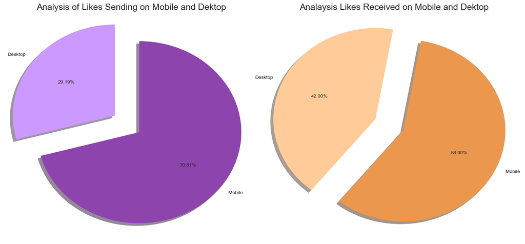

```python
# Visualization of total number of likes done and received likes on mobile and desktop.
fig = plt.figure(figsize=(15,7))

plt.subplot(1,2,1)
values=[fbd.www_likes.sum(), fbd.mobile_likes.sum()]
labels=['Desktop','Mobile']
explode = (0.2, 0.1)
colors = ['#cc99ff','#8E44AD']
plt.pie(values, colors=colors, labels=labels, autopct='%1.2f%%', shadow=True, startangle=90, explode=explode)
plt.title('Analysis of Likes Sending on Mobile and Dektop', fontsize=18)

plt.subplot(1,2,2)
values=[fbd.www_likes_received.sum(), fbd.mobile_likes_received.sum()]
labels=['Desktop','Mobile']
explode = (0.2, 0.1)
colors = ['#ffcc99','#EB984E']
plt.pie(values, colors=colors, labels=labels, autopct='%1.2f%%',shadow=True, startangle=80, explode=explode)
plt.title('Analaysis Likes Received on Mobile and Dektop',fontsize=18)

plt.tight_layout()
plt.show()
```

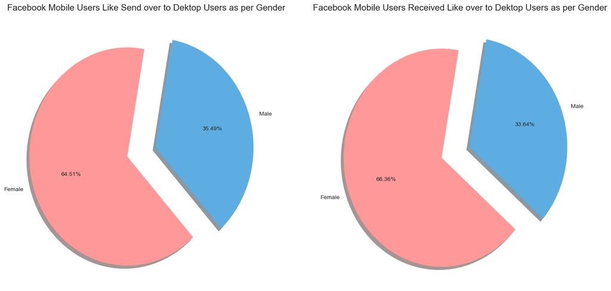

```python
# Visulaization of total number of likes send and received likes as per their gender.
fig = plt.figure(figsize=(15,7))
centre_circle = plt.Circle((0,0),0.50,fc='white')
fig = plt.gcf()
fig.gca().add_artist(centre_circle)
plt.axis('equal')

plt.subplot(1,2,1)
mobile_over_desktop_likes_done = fbd[(fbd['mobile_likes'] >= fbd['www_likes'])].groupby(['gender'])['mobile_likes'].sum()
colors = ['#ff9999','#5DADE2']  # FE, # MA
explode = (0.2, 0.1)
labels=['Female','Male']
plt.pie(mobile_over_desktop_likes_done, labels=labels, explode=explode, autopct='%1.2f%%', shadow=True, colors=colors, startangle=80)
plt.title('Facebook Mobile Users Like Send over to Dektop Users as per Gender', fontsize=15)

plt.subplot(1,2,2)
mobile_over_desktop_likes_received = fbd[(fbd['mobile_likes_received'] >= fbd['www_likes_received'])].groupby(['gender'])['mobile_likes_received'].sum()
colors = ['#ff9999','#5DADE2']  # FE, # MA
explode = (0.2, 0.1)
labels=['Female','Male']
plt.pie(mobile_over_desktop_likes_received, labels=labels, explode=explode, autopct='%1.2f%%', shadow=True, colors=colors, startangle=80)
plt.title('Facebook Mobile Users Received Like over to Dektop Users as per Gender', fontsize=15)

plt.tight_layout()
plt.show()
```

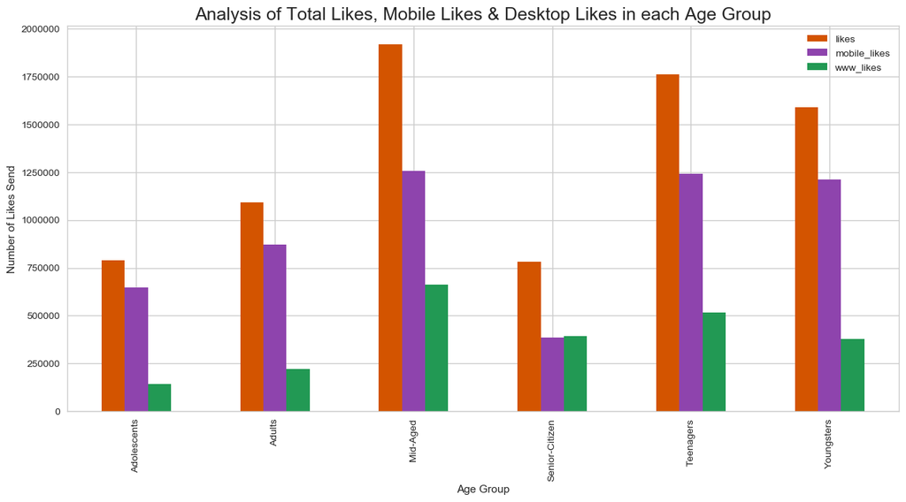

```python
# Visualization of total likes send in comparision of both mobile and desktop in different age group.

total_like_analysis = fbd[['likes','mobile_likes','www_likes']].groupby(fbd['Age_Group']).sum()
like_colors = ['#D35400','#8E44AD','#229954']
total_like_analysis.plot(kind='bar', subplots=False, color=like_colors,figsize=(15,7))
locs, title = plt.xticks()
plt.xticks(locs) #('0-13','13-20','20-25','25-30','30-40','40-60','60-100')
plt.title('Analysis of Total Likes, Mobile Likes & Desktop Likes in each Age Group', fontsize=18)
plt.ylabel('Number of Likes Send')
plt.xlabel('Age Group')
plt.show()
```

```python
# Resetting index of total_like_analysis column
total_like_analysis.reset_index() #(drop=True, inplace=True)
```

|  | Age_Group | likes | mobile_likes | www_likes |
| --- | --- | --- | --- | --- |
| 0 | Adolescents | 789618 | 646685 | 142933 |
| 1 | Adults | 1094092 | 873300 | 220792 |
| 2 | Mid-Aged | 1919291 | 1256195 | 663094 |
| 3 | Senior-Citizen | 780947 | 387629 | 393318 |
| 4 | Teenagers | 1762179 | 1243674 | 518505 |
| 5 | Youngsters | 1590257 | 1212317 | 377940 |

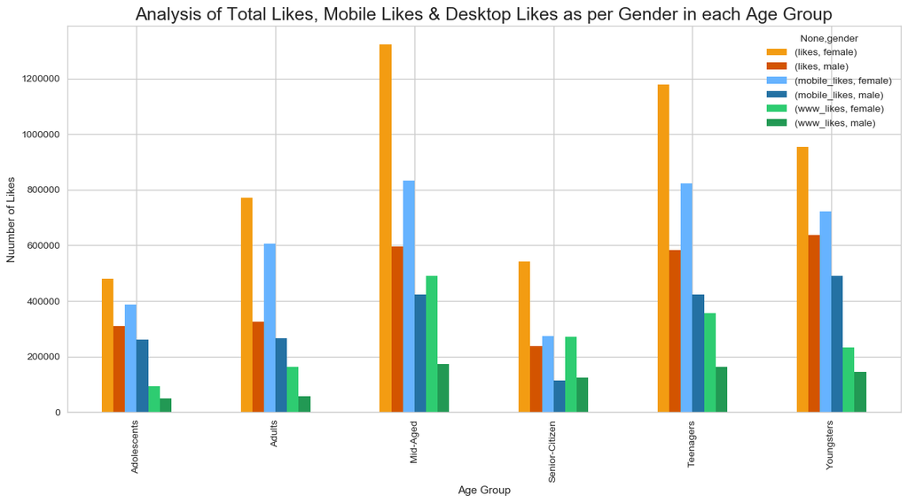

```python
# Visualization of total likes send in comparision of both mobile and desktop as per their gender in different age group.

gender_like_analysis = fbd[['likes','mobile_likes','www_likes']].groupby([fbd['Age_Group'],fbd['gender']]).sum()
gender_like_colors = ['#F39C12','#D35400','#66b3ff','#2471A3','#2ECC71','#229954']
gender_like_analysis.unstack('gender').plot(kind='bar', subplots=False, color=gender_like_colors, figsize=(15,7))
locs, title = plt.xticks()
plt.xticks(locs) #('0-13','13-20','20-25','25-30','30-40','40-60','60-100')
plt.title('Analysis of Total Likes, Mobile Likes & Desktop Likes as per Gender in each Age Group', fontsize=18)
plt.ylabel('Nuumber of Likes')
plt.xlabel('Age Group')
plt.show()
```

<font color=green> **Observation:** Above graphs shows that Female Mobile Useres are more active in Likeing posts in FB than Males, topped by Mid-Aged Females followed by Teenages and then Youngester. </font>

```python
# Resetting index of gender_like_analysis column
gender_like_analysis.reset_index()
```

|  | Age_Group | gender | likes | mobile_likes | www_likes |
| --- | --- | --- | --- | --- | --- |
| 0 | Adolescents | female | 478727 | 386310 | 92417 |
| 1 | Adolescents | male | 310891 | 260375 | 50516 |
| 2 | Adults | female | 769778 | 606521 | 163257 |
| 3 | Adults | male | 324314 | 266779 | 57535 |
| 4 | Mid-Aged | female | 1322779 | 832949 | 489828 |
| 5 | Mid-Aged | male | 596512 | 423246 | 173266 |
| 6 | Senior-Citizen | female | 542582 | 272675 | 269907 |
| 7 | Senior-Citizen | male | 238365 | 114954 | 123411 |
| 8 | Teenagers | female | 1178229 | 821688 | 356541 |
| 9 | Teenagers | male | 583950 | 421986 | 161964 |
| 10 | Youngsters | female | 954063 | 721124 | 232939 |
| 11 | Youngsters | male | 636194 | 491193 | 145001 |

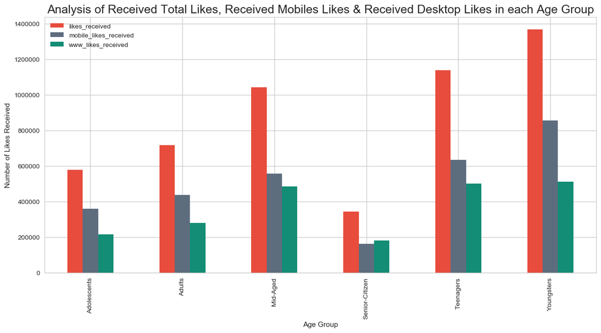

```python
# Visualization of total likes received in comparision of both mobile and desktop in different age group.
like_received_analysis = fbd[['likes_received','mobile_likes_received','www_likes_received']].groupby(fbd['Age_Group']).sum()
like_received_colors = ['#E74C3C','#5D6D7E','#138D75']
like_received_analysis.plot(kind='bar', subplots=False, color=like_received_colors, figsize=(15,7))
locs, title = plt.xticks()
plt.xticks(locs) #('0-13','13-20','20-25','25-30','30-40','40-60','60-100')
plt.title('Analysis of Received Total Likes, Received Mobiles Likes & Received Desktop Likes in each Age Group', fontsize=18)
plt.ylabel('Number of Likes Received')
plt.xlabel('Age Group')
plt.show()
```

<font color=green> **Observation:** Above graphs shows that all the Age Group Received Likes more in Mobile version of Facebook, topped by Youngesters followed by Teenages and Mid-Aged Users with an exception in Senior Citizen group. </font>

```python
# Resetting index of like_received_analysis column.
like_received_analysis.reset_index()
```

|  | Age_Group | likes_received | mobile_likes_received | www_likes_received |
| --- | --- | --- | --- | --- |
| 0 | Adolescents | 579515 | 361709 | 217806 |
| 1 | Adults | 718796 | 438055 | 280741 |
| 2 | Mid-Aged | 1042865 | 558014 | 484851 |
| 3 | Senior-Citizen | 343743 | 162134 | 181609 |
| 4 | Teenagers | 1138435 | 636320 | 502114 |
| 5 | Youngsters | 1369036 | 855433 | 513603 |